# Project: Investigate a Dataset (Medical No Show)

- Introduction
- Data Wrangling
- Exploratory Data Analysis
- Conclusions

## Introduction

This dataset collects information from 100k medical appointments in Brazil and is focused on the question of whether or not patients show up for their appointment. A number of characteristics about the patient are included in each row.

The questions that will be answered will be two typical sterotypes - 1. Does older people tned to book and plan eariler than younger people? And 2. Are people who frequent doctors more healthy?

```python
import pandas as pd
import numpy as np
import matplotlib.pyplot as plt
import seaborn as sns
%matplotlib inline
```

## Data Wrangling

### General Properties

```python
df = pd.read_csv('noshowappointments-may-2016.csv')
```

```python
df.head()
```

|  | PatientId | AppointmentID | Gender | ScheduledDay | AppointmentDay | Age | Neighbourhood | Scholarship | Hipertension | Diabetes | Alcoholism | Handcap | SMS_received | No-show |
| --- | --- | --- | --- | --- | --- | --- | --- | --- | --- | --- | --- | --- | --- | --- |
| 0 | 2.987250e+13 | 5642903 | F | 2016-04-29T18:38:08Z | 2016-04-29T00:00:00Z | 62 | JARDIM DA PENHA | 0 | 1 | 0 | 0 | 0 | 0 | No |
| 1 | 5.589978e+14 | 5642503 | M | 2016-04-29T16:08:27Z | 2016-04-29T00:00:00Z | 56 | JARDIM DA PENHA | 0 | 0 | 0 | 0 | 0 | 0 | No |
| 2 | 4.262962e+12 | 5642549 | F | 2016-04-29T16:19:04Z | 2016-04-29T00:00:00Z | 62 | MATA DA PRAIA | 0 | 0 | 0 | 0 | 0 | 0 | No |
| 3 | 8.679512e+11 | 5642828 | F | 2016-04-29T17:29:31Z | 2016-04-29T00:00:00Z | 8 | PONTAL DE CAMBURI | 0 | 0 | 0 | 0 | 0 | 0 | No |
| 4 | 8.841186e+12 | 5642494 | F | 2016-04-29T16:07:23Z | 2016-04-29T00:00:00Z | 56 | JARDIM DA PENHA | 0 | 1 | 1 | 0 | 0 | 0 | No |

#### Data Columns Explained

AppointmentID - Identification of each appointment

Gender = Male or Female . Female is the greater proportion, woman takes way more care of they health in comparison to man.

ScheduledDay = The day someone called or registered the appointment, this is before appointment of course.

AppointmentDay = The day of the actuall appointment, when they have to visit the doctor.

Age = How old is the patient.

Neighbourhood = Where the appointment takes place.

Scholarship = Ture of False . Observation, this is a broad topic, consider reading this article https://en.wikipedia.org/wiki/Bolsa_Fam%C3%ADlia

Hipertension = True or False

Diabetes = True or False

Alcoholism = True or False

No-show = True or False.

```python
df.shape
```

```
(110527, 14)
```

```python
df.describe()
```

|  | PatientId | AppointmentID | Age | Scholarship | Hipertension | Diabetes | Alcoholism | Handcap | SMS_received |
| --- | --- | --- | --- | --- | --- | --- | --- | --- | --- |
| count | 1.105270e+05 | 1.105270e+05 | 110527.000000 | 110527.000000 | 110527.000000 | 110527.000000 | 110527.000000 | 110527.000000 | 110527.000000 |
| mean | 1.474963e+14 | 5.675305e+06 | 37.088874 | 0.098266 | 0.197246 | 0.071865 | 0.030400 | 0.022248 | 0.321026 |
| std | 2.560949e+14 | 7.129575e+04 | 23.110205 | 0.297675 | 0.397921 | 0.258265 | 0.171686 | 0.161543 | 0.466873 |
| min | 3.921784e+04 | 5.030230e+06 | -1.000000 | 0.000000 | 0.000000 | 0.000000 | 0.000000 | 0.000000 | 0.000000 |
| 25% | 4.172614e+12 | 5.640286e+06 | 18.000000 | 0.000000 | 0.000000 | 0.000000 | 0.000000 | 0.000000 | 0.000000 |
| 50% | 3.173184e+13 | 5.680573e+06 | 37.000000 | 0.000000 | 0.000000 | 0.000000 | 0.000000 | 0.000000 | 0.000000 |
| 75% | 9.439172e+13 | 5.725524e+06 | 55.000000 | 0.000000 | 0.000000 | 0.000000 | 0.000000 | 0.000000 | 1.000000 |
| max | 9.999816e+14 | 5.790484e+06 | 115.000000 | 1.000000 | 1.000000 | 1.000000 | 1.000000 | 4.000000 | 1.000000 |

```python
df.info()
```

```
<class 'pandas.core.frame.DataFrame'>
RangeIndex: 110527 entries, 0 to 110526
Data columns (total 14 columns):
PatientId         110527 non-null float64
AppointmentID     110527 non-null int64
Gender            110527 non-null object
ScheduledDay      110527 non-null object
AppointmentDay    110527 non-null object
Age               110527 non-null int64
Neighbourhood     110527 non-null object
Scholarship       110527 non-null int64
Hipertension      110527 non-null int64
Diabetes          110527 non-null int64
Alcoholism        110527 non-null int64
Handcap           110527 non-null int64
SMS_received      110527 non-null int64
No-show           110527 non-null object
dtypes: float64(1), int64(8), object(5)
memory usage: 11.8+ MB
```

### Data Cleaning

```python
df.rename(columns={'No-show': 'no_show'}, inplace= True)
df.rename(columns=lambda x: x.strip().lower().replace(" ",""), inplace=True)
```

Rename No-show to no_show and renaming every column to delete space and all lower case

```python
def convert_to_datetime():
    df['scheduledday'] = pd.to_datetime(df['scheduledday'])
    df['appointmentday'] = pd.to_datetime(df['appointmentday'])
    return df.head(1)
convert_to_datetime()
```

|  | patientid | appointmentid | gender | scheduledday | appointmentday | age | neighbourhood | scholarship | hipertension | diabetes | alcoholism | handcap | sms_received | no_show |
| --- | --- | --- | --- | --- | --- | --- | --- | --- | --- | --- | --- | --- | --- | --- |
| 0 | 2.987250e+13 | 5642903 | F | 2016-04-29 18:38:08 | 2016-04-29 | 62 | JARDIM DA PENHA | 0 | 1 | 0 | 0 | 0 | 0 | No |

function for converting date time from str to datetime

```python
df['scheduleddate'] = [d.date() for d in df['scheduledday']]
df['scheduledtime'] = [d.time() for d in df['scheduledday']]
df['appointmentdate'] = [d.date() for d in df['appointmentday']]
df['appointmenttime'] = [d.time() for d in df['appointmentday']]
df.drop(['scheduledday','appointmentday'], axis=1, inplace=True)
```

Change the ScheduledDay and AppointmentDay from str to date time format then split ScheduledDay and AppointmentDay into sperate date and time colums ScheduledDate, ScheduledTime, AppointmentDate, AppointmentTime.

```python
df['no_show']= df['no_show'].map({'Yes':1, 'No':0}).astype(int)
```

```python
df.head(5)
```

|  | patientid | appointmentid | gender | age | neighbourhood | scholarship | hipertension | diabetes | alcoholism | handcap | sms_received | no_show | scheduleddate | scheduledtime | appointmentdate | appointmenttime |
| --- | --- | --- | --- | --- | --- | --- | --- | --- | --- | --- | --- | --- | --- | --- | --- | --- |
| 0 | 2.987250e+13 | 5642903 | F | 62 | JARDIM DA PENHA | 0 | 1 | 0 | 0 | 0 | 0 | 0 | 2016-04-29 | 18:38:08 | 2016-04-29 | 00:00:00 |
| 1 | 5.589978e+14 | 5642503 | M | 56 | JARDIM DA PENHA | 0 | 0 | 0 | 0 | 0 | 0 | 0 | 2016-04-29 | 16:08:27 | 2016-04-29 | 00:00:00 |
| 2 | 4.262962e+12 | 5642549 | F | 62 | MATA DA PRAIA | 0 | 0 | 0 | 0 | 0 | 0 | 0 | 2016-04-29 | 16:19:04 | 2016-04-29 | 00:00:00 |
| 3 | 8.679512e+11 | 5642828 | F | 8 | PONTAL DE CAMBURI | 0 | 0 | 0 | 0 | 0 | 0 | 0 | 2016-04-29 | 17:29:31 | 2016-04-29 | 00:00:00 |
| 4 | 8.841186e+12 | 5642494 | F | 56 | JARDIM DA PENHA | 0 | 1 | 1 | 0 | 0 | 0 | 0 | 2016-04-29 | 16:07:23 | 2016-04-29 | 00:00:00 |

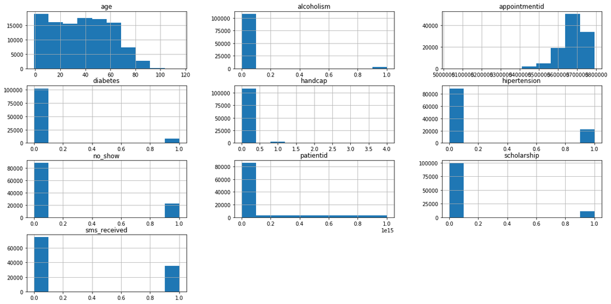

```python
df.hist(figsize=(20,10));
```

Here we can start to see some trends.

## Exploratory Data Analysis

### Does older people schedual their appoint more in advanced?

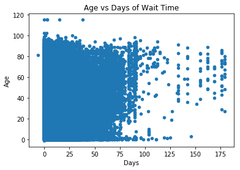

```python
df['waitdays'] = df.appointmentdate - df.scheduleddate
df.waitdays = df.waitdays.dt.days
df.plot(x='waitdays', y='age', kind='scatter')
plt.title('Age vs Days of Wait Time')
plt.xlabel('Days')
plt.ylabel('Age');
```

Here we have a scatter plot showing the amount of time people schedual their appointment in advance compare to their age. Based on this information, older people does not schedual their time more in advanced compared to younger people.

### How healthy are the people going to the appointments?

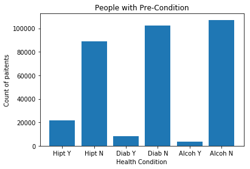

```python
hipertension_yes = df.query('hipertension == 1')['age'].count()
hipertension_no = df.query('hipertension == 0')['age'].count()
diabetes_yes = df.query('diabetes == 1')['age'].count()
diabetes_no = df.query('diabetes == 0')['age'].count()
alcoholism_yes = df.query('alcoholism == 1')['age'].count()
alcoholism_no = df.query('alcoholism == 0')['age'].count()
locations = [1, 2, 3, 4, 5, 6]
heights = [hipertension_yes, hipertension_no, diabetes_yes, diabetes_no, alcoholism_yes, alcoholism_no]
labels = ['Hipt Y', 'Hipt N', 'Diab Y', 'Diab N', 'Alcoh Y', 'Alcoh N']
plt.bar(locations, heights, tick_label=labels)
plt.title('People with Pre-Condition')
plt.ylabel('Count of paitents')
plt.xlabel('Health Condition')
plt.rcParams["figure.figsize"] = [10,5]
```

By counting people with different conditions, this chart is able to be drawn. It appeares that majority amount of people does not have any serious pre-conditions.

## Conclusions

### Limitations

This data doesn't provide enough information for accurate prediction of if paitents will show up. For example the distance between the paitnet and the clinc and the reason paitent booked the apointment all are significant to predicting if paitent will show up for appointment or not.